# MSDS 6372 Project 2

## Data Set 1: Osteoporosis in Women

From Hosmer, Lemeshow, and Sturdivant (2013), Applied Logistic Regression, 3rd Edition. The Global Longitudinal Study of Osteoporosis in Women (GLOW) is an international study of osteoporosis in women aged 55 years and over. The major goals of the study are to examine prevention and treatment of fractures and distribution of risk factors among older women. Complete details on the study as well as a list of GLOW publications may be found at the Center for Outcomes Research web site, http://www.outcomes-umassmed.org/glow. There are over 60K observations in the original data set. This data set contains a sample of 500 of them. The link below is to a website with the data set and description of the variables. The data set in question is called “glow500”.

https://www.umass.edu/statdata/statdata/data/glow/index.html Note: If you choose this data set, you MAY NOT use the Hosmer, Lemeshow, and Sturdivant text to help you in your analysis. You may only use Chapter 1 in order to obtain a description of the data.

Of course if you dont have the book

https://www.umass.edu/statdata/statdata/data/glow/glow.pdf provides definitions to the variables.

The Global Longitudinal Study of Osteoporosis in Women (GLOW) (2005-2014) was a prospective cohort study of physician practices in the provision of prophylaxis and treatment against osteoporotic fractures. The goal of this research was to improve understanding of the risk and prevention of osteoporosis-related fractures among female residents of 10 countries who were 55 years of age and older. GLOW enrolled over 60,000 women through over 700 physicians in 10 countries, and conducted annual follow-up for up to 5 years through annual patient questionnaires.

# Setup:

## Data Import and Cleaning

Missing values were not detected in dataset. Special characters were removed from column headings.  
What we know/don’t know about the sample (500): 1. We do not know if the subjects are distributed equally around the world. We will assume that the same percentage from each region was selected for the sample in this dataset. 2. Based on the Sub_ID(Subject ID), we can assume that the datat is independent sample of participants.

```r
glow_data_file <- here::here("data", "glow500.csv")
dataset_loc <-
dataset <- read.csv(glow_data_file, sep=",", stringsAsFactors = TRUE, header=TRUE,na.strings=c(""))

# List rows of data that have missing values
Missing_values <- dataset[!complete.cases(dataset),]

# Create new dataset without missing data
dataset <- na.omit(dataset)

#remove FRACSCORE feature per professor Turner
drops <- c("FRACSCORE")
dataset <- dataset[ , !(names(dataset) %in% drops)]

#Cleanup column names
colnames(dataset)[colnames(dataset)=="ï..SUB_ID"] <- "SUB_ID"

#set categorical variables as factors
dataset$PRIORFRAC <- factor(dataset$PRIORFRAC,labels=c("0","1"))
dataset$PREMENO <- factor(dataset$PREMENO,labels=c("0","1"))
dataset$MOMFRAC <- factor(dataset$MOMFRAC,labels=c("0","1"))
dataset$ARMASSIST <- factor(dataset$ARMASSIST,labels=c("0","1"))
dataset$SMOKE <- factor(dataset$SMOKE,labels=c("0","1"))
dataset$RATERISK <- factor(dataset$RATERISK,labels=c("1","2","3"))
dataset$FRACTURE <- factor(dataset$FRACTURE,labels=c("0","1"))

#rearrange columns
dataset <- dataset[c("SUB_ID","SITE_ID","PHY_ID","AGE","BMI","HEIGHT","WEIGHT","PRIORFRAC","PREMENO","MOMFRAC","ARMASSIST","SMOKE","RATERISK","FRACTURE")]

str(dataset)
```

```
## 'data.frame':    500 obs. of  14 variables:
##  $ SUB_ID   : int  1 2 3 4 5 6 7 8 9 10 ...
##  $ SITE_ID  : int  1 4 6 6 1 5 5 1 1 4 ...
##  $ PHY_ID   : int  14 284 305 309 37 299 302 36 8 282 ...
##  $ AGE      : int  62 65 88 82 61 67 84 82 86 58 ...
##  $ BMI      : num  28.2 34 20.6 24.3 29.4 ...
##  $ HEIGHT   : int  158 160 157 160 152 161 150 153 156 166 ...
##  $ WEIGHT   : num  70.3 87.1 50.8 62.1 68 68 50.8 40.8 62.6 63.5 ...
##  $ PRIORFRAC: Factor w/ 2 levels "0","1": 1 1 2 1 1 2 1 2 2 1 ...
##  $ PREMENO  : Factor w/ 2 levels "0","1": 1 1 1 1 1 1 1 1 1 1 ...
##  $ MOMFRAC  : Factor w/ 2 levels "0","1": 1 1 2 1 1 1 1 1 1 1 ...
##  $ ARMASSIST: Factor w/ 2 levels "0","1": 1 1 2 1 1 1 1 1 1 1 ...
##  $ SMOKE    : Factor w/ 2 levels "0","1": 1 1 1 1 1 2 1 1 1 1 ...
##  $ RATERISK : Factor w/ 3 levels "1","2","3": 2 2 1 1 2 2 1 2 2 1 ...
##  $ FRACTURE : Factor w/ 2 levels "0","1": 1 1 1 1 1 1 1 1 1 1 ...
```

# Exploratory Data Analysis

## Grouping Variables as Continuous, Categorical, and ID

```r
numericVar <- dataset[,4:7]
ID_var <- dataset[,c(1:3)]
set_noID <- dataset[4:14]
categoricalVar <- dataset[8:14]
```

## Create Train and Validation Datasets

```r
validation_index = createDataPartition(dataset$FRACTURE, p=0.70, list=FALSE)
validationData = dataset[-validation_index,c(4:14)]
trainingData = dataset[validation_index,c(4:14)]
```

## Summary Statistics

```r
#Summary stats by groups for continous predictors
t(aggregate(AGE~FRACTURE,data=dataset,summary))
```

```
##             [,1]       [,2]
## FRACTURE    "0"        "1"
## AGE.Min.    "55.00000" "56.00000"
## AGE.1st Qu. "60.00000" "65.00000"
## AGE.Median  "66.00000" "72.00000"
## AGE.Mean    "67.48533" "71.79200"
## AGE.3rd Qu. "74.00000" "79.00000"
## AGE.Max.    "90.00000" "89.00000"
```

```r
t(aggregate(BMI~FRACTURE,data=dataset,summary))
```

```
##             [,1]       [,2]
## FRACTURE    "0"        "1"
## BMI.Min.    "14.87637" "17.04223"
## BMI.1st Qu. "23.32087" "23.04688"
## BMI.Median  "26.36709" "26.43080"
## BMI.Mean    "27.50140" "27.70793"
## BMI.3rd Qu. "30.61756" "31.09282"
## BMI.Max.    "49.08241" "44.03628"
```

```r
t(aggregate(WEIGHT~FRACTURE,data=dataset,summary))
```

```
##                [,1]        [,2]
## FRACTURE       "0"         "1"
## WEIGHT.Min.    " 39.90000" " 45.80000"
## WEIGHT.1st Qu. " 60.30000" " 59.90000"
## WEIGHT.Median  " 68.00000" " 68.00000"
## WEIGHT.Mean    " 72.16693" " 70.79200"
## WEIGHT.3rd Qu. " 81.60000" " 79.40000"
## WEIGHT.Max.    "127.00000" "124.70000"
```

```r
t(aggregate(HEIGHT~FRACTURE,data=dataset,summary))
```

```
##                [,1]      [,2]
## FRACTURE       "0"       "1"
## HEIGHT.Min.    "142.000" "134.000"
## HEIGHT.1st Qu. "158.000" "155.000"
## HEIGHT.Median  "162.000" "160.000"
## HEIGHT.Mean    "161.864" "159.864"
## HEIGHT.3rd Qu. "166.000" "164.000"
## HEIGHT.Max.    "199.000" "178.000"
```

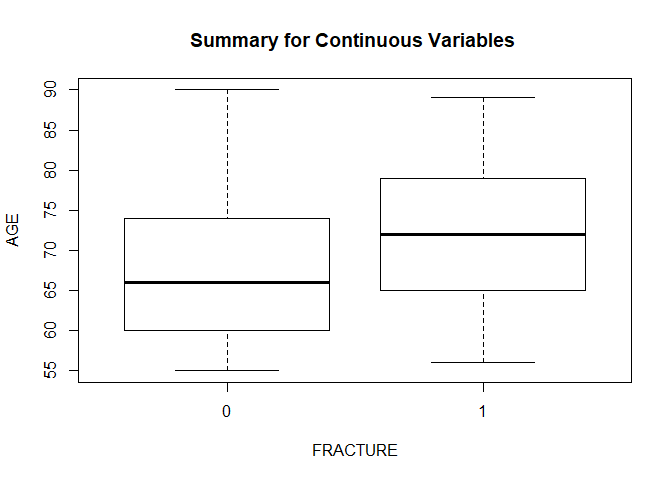

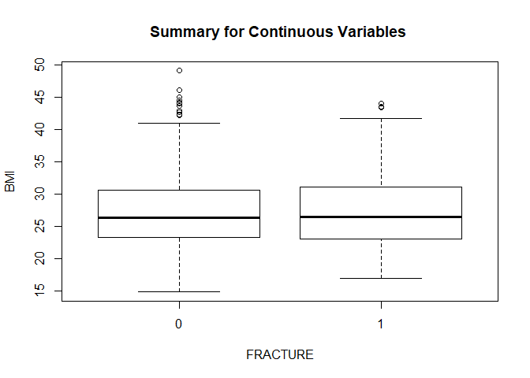

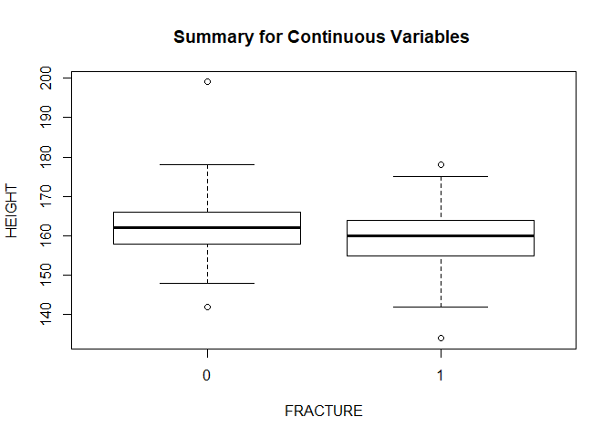

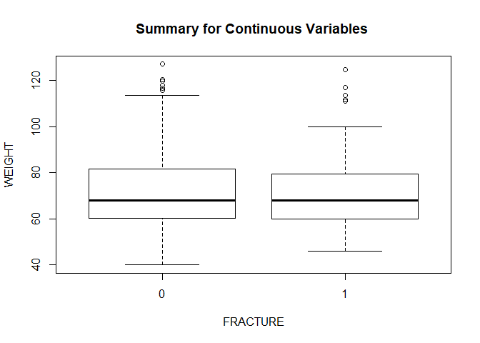

```r
#par(mfrow=c(2,2)) # put four figures in a row (2*4)
for (i in 4:7) {
  boxplot(dataset[,i] ~ dataset$FRACTURE,ylab=names(dataset)[i],xlab="FRACTURE", main="Summary for Continuous Variables ")
}
```

```r
set.seed(999)
validation_index = createDataPartition(dataset$FRACTURE, p=0.70, list=FALSE)
validationData = dataset[-validation_index,c(4:14)]
trainingData = dataset[validation_index,c(4:14)]

table(dataset$FRACTURE)
```

```
##
##   0   1
## 375 125
```

```r
table(trainingData$FRACTURE)
```

```
##
##   0   1
## 263  88
```

```r
table(validationData$FRACTURE)
```

```
##
##   0   1
## 112  37
```

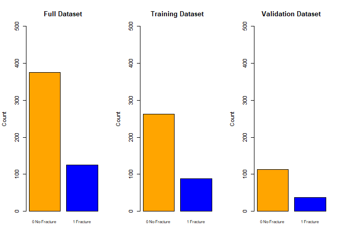

```r
#BarPlots of Fracture counts between full, training and validation datasets.
par(mfrow=c(1,3))
#par(mar=c(5,8,4,2)) # increase y-axis margin.
count_full <- table(dataset$FRACTURE)
count_trn <- table(trainingData$FRACTURE)
count_test <- table(validationData$FRACTURE)


barplot(count_full,main="Full Dataset", ylab="Count", col=c("orange","blue"),names.arg=c("0 No Fracture", "1 Fracture"), cex.names=0.8,ylim=c(0 , 500))

barplot(count_trn,main="Training Dataset", ylab="Count", col=c("orange","blue"),names.arg=c("0 No Fracture", "1 Fracture"), cex.names=0.8,ylim=c(0 , 500))

barplot(count_test,main="Validation Dataset", ylab="Count", col=c("orange","blue"),names.arg=c("0 No Fracture", "1 Fracture"), cex.names=0.8,ylim=c(0 , 500))
```

```r
#create an nicer summary table
index<-which(sapply(dataset,is.numeric))
tab.cont<-c()
for (i in index){
  tab.cont<-rbind(tab.cont,summary(dataset[,i]))
}
rownames(tab.cont)<-names(dataset)[index]
View(tab.cont)
tab.cont
```

```
##              Min.   1st Qu.    Median      Mean   3rd Qu.      Max.
## SUB_ID    1.00000 125.75000 250.50000 250.50000 375.25000 500.00000
## SITE_ID   1.00000   2.00000   3.00000   3.43600   5.00000   6.00000
## PHY_ID    1.00000  57.75000 182.50000 178.55000 298.00000 325.00000
## AGE      55.00000  61.00000  67.00000  68.56200  76.00000  90.00000
## BMI      14.87637  23.26889  26.41898  27.55303  30.79205  49.08241
## HEIGHT  134.00000 157.00000 161.50000 161.36400 165.00000 199.00000
## WEIGHT   39.90000  59.90000  68.00000  71.82320  81.30000 127.00000
```

```r
# display the first 20 rows
print(head(dataset, n=20))
```

```
##    SUB_ID SITE_ID PHY_ID AGE      BMI HEIGHT WEIGHT PRIORFRAC PREMENO
## 1       1       1     14  62 28.16055    158   70.3         0       0
## 2       2       4    284  65 34.02344    160   87.1         0       0
## 3       3       6    305  88 20.60936    157   50.8         1       0
## 4       4       6    309  82 24.25781    160   62.1         0       0
## 5       5       1     37  61 29.43213    152   68.0         0       0
## 6       6       5    299  67 26.23356    161   68.0         1       0
## 7       7       5    302  84 22.57778    150   50.8         0       0
## 8       8       1     36  82 17.42919    153   40.8         1       0
## 9       9       1      8  86 25.72321    156   62.6         1       0
## 10     10       4    282  58 23.04398    166   63.5         0       0
## 11     11       6    315  67 28.87778    153   67.6         0       0
## 12     12       1     34  56 42.27473    167  117.9         0       0
## 13     13       6    315  59 25.56775    162   67.1         0       0
## 14     14       1     33  72 21.15702    165   57.6         0       0
```

[output cut: 27 more lines]

```r
# display the dimensions of the dataset
print(dim(dataset))
```

```
## [1] 500  14
```

```r
# list types for each attribute
print(sapply(dataset,class))
```

```
##    SUB_ID   SITE_ID    PHY_ID       AGE       BMI    HEIGHT    WEIGHT
## "integer" "integer" "integer" "integer" "numeric" "integer" "numeric"
## PRIORFRAC   PREMENO   MOMFRAC ARMASSIST     SMOKE  RATERISK  FRACTURE
##  "factor"  "factor"  "factor"  "factor"  "factor"  "factor"  "factor"
```

```r
# Standard Deviations for the non-categorical columns
std=sapply(set_noID,sd)
print('The standard deviations are:')
```

```
## [1] "The standard deviations are:"
```

```r
print(std)
```

```
##        AGE        BMI     HEIGHT     WEIGHT  PRIORFRAC    PREMENO
##  8.9895372  5.9739583  6.3554928 16.4359918  0.4345961  0.3958249
##    MOMFRAC  ARMASSIST      SMOKE   RATERISK   FRACTURE
##  0.3366402  0.4848651  0.2554025  0.7922470  0.4334464
```

### Correlations

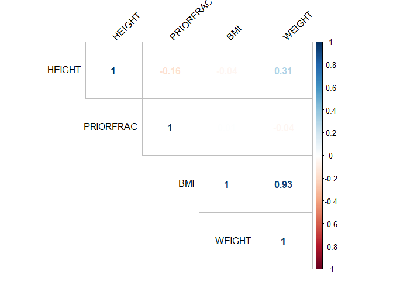

```r
#Training dataset without ID columns, convert PRIORFRAC to numeric for corrplot
train_df <- trainingData[2:5]
train_df$PRIORFRAC <- as.numeric(train_df$PRIORFRAC)
corrplot(cor(train_df), method = "number", type = "upper", order = "hclust",
         tl.col = "black", tl.srt = 45)
```

### Visualization of Continuous Variables For the categorical variables, we show an unbalanced dataset of subjects with majority false PRIORFRAC, PREMENO, MOMFRAC, ARMASSIST, and SMOKE. There was a good balance of subjects in the 3 levels of RATERISK. An unblanced dataset will cause a model to favor the skewed numbers.

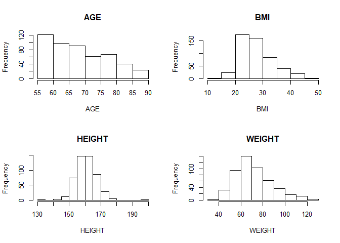

```r
# Data visualizations
dataset_numeric = numericVar

#Histograms
par(mfrow=c(2,2))
for (i in 1:4) {
  hist(dataset_numeric[,i],xlab=names(dataset_numeric)[i],main=names(dataset_numeric)[i])
}
```

In the full dataset we have a majority of subjects are younger. The range of ages is between 55-90.

About 300 out of 500 subjects are in the 20-30 BMI score range.

We show a majority of subjects are in the weight range of 60-80.

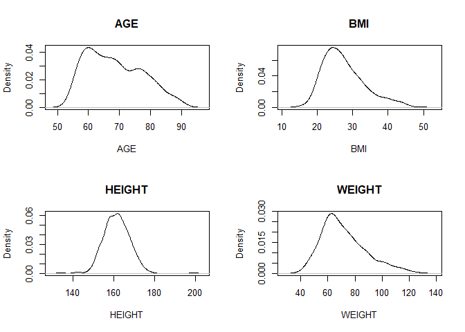

```r
#Density Plots
par(mfrow=c(2,2))
for(i in 1:4) {
  plot(density(dataset_numeric[,i]), xlab=names(dataset_numeric)[i], main=names(dataset_numeric)[i])
}
```

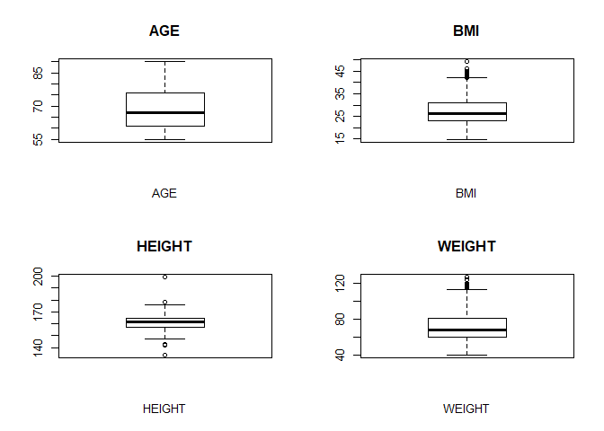

```r
#Box And Whisker Plots
par(mfrow=c(2,2))
for(i in 1:4) {
  boxplot(dataset_numeric[,i], xlab=names(dataset_numeric)[i], main=names(dataset_numeric)[i])
}
```

Frequency counts of subjects with Fracture. Compare Full, Train and Validation

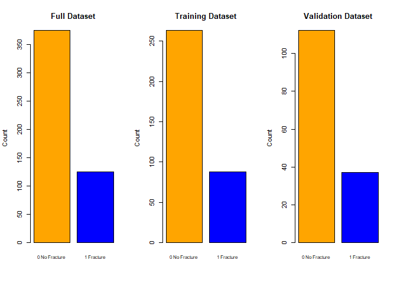

```r
par(mfrow=c(1,3))
#par(mar=c(5,8,4,2)) # increase y-axis margin.
count_full <- table(dataset$FRACTURE)
count_trn <- table(trainingData$FRACTURE)
count_test <- table(validationData$FRACTURE)


barplot(count_full,main="Full Dataset", ylab="Count", col=c("orange","blue"),names.arg=c("0 No Fracture", "1 Fracture"), cex.names=0.8)

barplot(count_trn,main="Training Dataset", ylab="Count", col=c("orange","blue"),names.arg=c("0 No Fracture", "1 Fracture"), cex.names=0.8)

barplot(count_test,main="Validation Dataset", ylab="Count", col=c("orange","blue"),names.arg=c("0 No Fracture", "1 Fracture"), cex.names=0.8)
```

```r
#Multivariate Visualization
correlations1=cor(dataset_numeric)
print(correlations1)
```

```
##               AGE         BMI      HEIGHT     WEIGHT
## AGE     1.0000000 -0.22125651 -0.19264861 -0.2715964
## BMI    -0.2212565  1.00000000 -0.02437689  0.9373360
## HEIGHT -0.1926486 -0.02437689  1.00000000  0.3159691
## WEIGHT -0.2715964  0.93733603  0.31596915  1.0000000
```

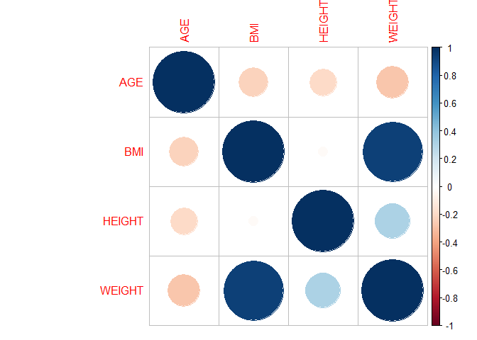

```r
par(mfrow=c(1,1))
corrplot(correlations1, methods="circle")
```

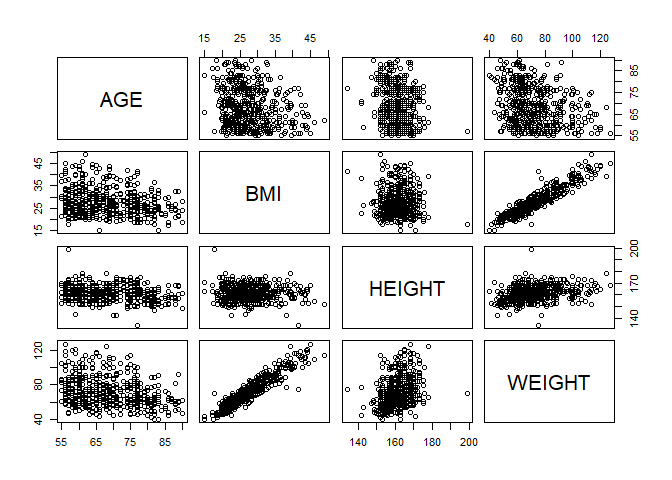

```r
# pair-wise scatterplots of the numeric attributes
par(mfrow=c(1,1))
pairs(dataset_numeric)
```

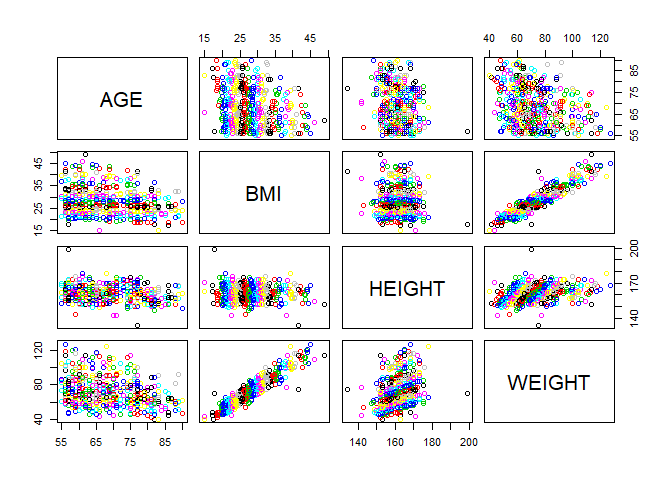

```r
#Scatterplot Matrix By Class (use different color to distinguish different class)
par(mfrow=c(1,1))
pairs(dataset_numeric, col=dataset[,5])
```

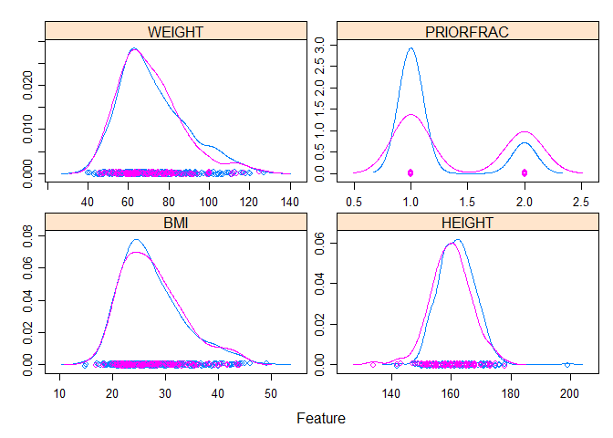

```r
# density plots for each attribute by class value
X <- set_noID[2:5]
Y <- set_noID$FRACTURE
X$PRIORFRAC <- as.numeric(X$PRIORFRAC)
scales <- list(x=list(relation="free"), y=list(relation="free"))
par(mfrow=c(1,1))
featurePlot(x=X, y=set_noID$FRACTURE, plot="density", scales=scales)
```

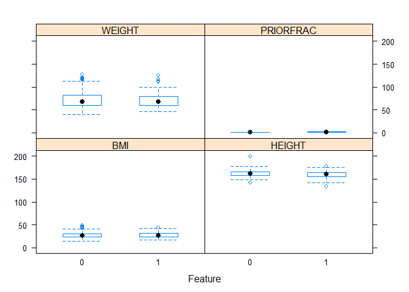

```r
#Box And Whisker Plots By Class
par(mfrow=c(1,1))
featurePlot(x=X, y=set_noID$FRACTURE, plot="box")
```

## Checking the Balance of the Full dataset

The current sample dataset containes a larger propotion of subjects that did not develop fracture. Building a model against this dataset could produce bias towards the majority class. Below you will see how many subjects with(1)/without(0) Fractures as well as the proportion percentage for each. After splitting the dataset into training and validation(test) sets, we noticed the proportion of the training and test was not any better.

```r
table(dataset$FRACTURE)
```

```
##
##   0   1
## 375 125
```

```r
prop.table(table(dataset$FRACTURE))
```

```
##
##    0    1
## 0.75 0.25
```

```r
# split the data into training and validation sets
set.seed(84)
validation_index = createDataPartition(dataset$FRACTURE, p=0.75, list=FALSE)
validationData = dataset[-validation_index,c(4:14)]
trainingData = dataset[validation_index,c(4:14)]
prop.table(table(validationData$FRACTURE))
```

```
##
##    0    1
## 0.75 0.25
```

```r
prop.table(table(trainingData$FRACTURE))
```

```
##
##    0    1
## 0.75 0.25
```

```r
#fit a logistic regressio to unblanced training set
fit.dataset <- glm(formula=FRACTURE~ ., data = trainingData, family="binomial")
pred.fit.dataset <- predict(fit.dataset, newdata = validationData, type="response")
#Check Accuracy of fitted model.
accuracy.meas(validationData$FRACTURE,pred.fit.dataset, threshold=.05)
```

```
##
## Call:
## accuracy.meas(response = validationData$FRACTURE, predicted = pred.fit.dataset,
##     threshold = 0.05)
##
## Examples are labelled as positive when predicted is greater than 0.05
##
## precision: 0.250
## recall: 1.000
## F: 0.200
```

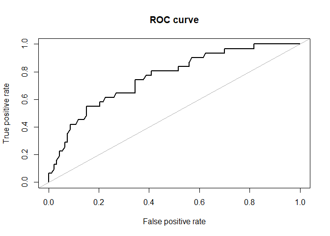

```
## Area under the curve (AUC): 0.760
```

```r
#Check Accuracy of Test dataset using ROC curve
roc.curve(validationData$FRACTURE, pred.fit.dataset, plotit = TRUE)
```

##Create a vector of all categorical variables and run frequency 2X2s with Mosaic plots.

Chi-Square Test  
For the 2-way tables the chisq test independence will show if 2 categorical variables are related in some population.  
Null Hypothesis: The two categorical variables are independent.  
Alternative Hypothesis: The two categorical variables are dependent

Variable: PRIORFRAC 41% of subjects with Prior Franctures also had current Fractures but only make up 25% of the overall subjects in the sample that had prior fractures. The Chi-squared p-value favors overwhemingly the alternative hypothesis that the PRIORFRAC variable is dependent on Fracture variable.

Variable: PREMENO 80% of the sample subjects are not in Pre-Menopausehad of which 24% had fractures. The same frequency of 25% Premenopausal women had fractures. The Chi-squared p-value favors the null hypothesis that the PREMENO variable is independent on Fracture variable.

Variable: MOMFRAC 13% of subjects have Mothers with a history of fractures. Out of those 13%, 36% of subjects also had fractures. The Chi-squared p-value favors the alternative hypothesis that the MOMFRAC variable is probably dependent on Fracture variable.

Variable: ARMASSIST 62% (312/500) subjects do not have Armassist of which 20% had fractures. Of those with Armassist, 33% had fractures. The Chi-squared p-value favors the alternative hypothesis that the ARMASSIST variable is most likely dependent on Fracture variable.

```
##
##
##    Cell Contents
## |-------------------------|
## |                       N |
## |              Expected N |
## | Chi-square contribution |
## |           N / Row Total |
## |           N / Col Total |
## |         N / Table Total |
## |-------------------------|
##
##
## Total Observations in Table:  500
##
##
##              | FRACTURE
##    PRIORFRAC |         0 |         1 | Row Total |
## -------------|-----------|-----------|-----------|
##            0 |       301 |        73 |       374 |
##              |   280.500 |    93.500 |           |
##              |     1.498 |     4.495 |           |
##              |     0.805 |     0.195 |     0.748 |
##              |     0.803 |     0.584 |           |
##              |     0.602 |     0.146 |           |
## -------------|-----------|-----------|-----------|
##            1 |        74 |        52 |       126 |
##              |    94.500 |    31.500 |           |
##              |     4.447 |    13.341 |           |
##              |     0.587 |     0.413 |     0.252 |
##              |     0.197 |     0.416 |           |
##              |     0.148 |     0.104 |           |
## -------------|-----------|-----------|-----------|
## Column Total |       375 |       125 |       500 |
##              |     0.750 |     0.250 |           |
## -------------|-----------|-----------|-----------|
##
##
## Statistics for All Table Factors
##
```

[output cut: 30 more lines]

```
##                           |     0.805 |     0.195 |     0.748 |
##                           |     0.803 |     0.584 |           |
##                           |     0.602 |     0.146 |           |
## --------------------------|-----------|-----------|-----------|
##                         1 |        74 |        52 |       126 |
##                           |     4.447 |    13.341 |           |
##                           |     0.587 |     0.413 |     0.252 |
##                           |     0.197 |     0.416 |           |
##                           |     0.148 |     0.104 |           |
## --------------------------|-----------|-----------|-----------|
##              Column Total |       375 |       125 |       500 |
##                           |     0.750 |     0.250 |           |
## --------------------------|-----------|-----------|-----------|
##
##
```

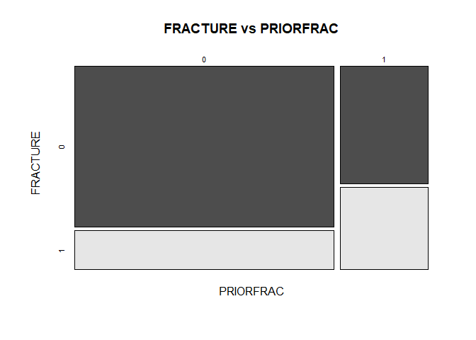

```
##
##
##    Cell Contents
## |-------------------------|
## |                       N |
## |              Expected N |
## | Chi-square contribution |
## |           N / Row Total |
## |           N / Col Total |
## |         N / Table Total |
## |-------------------------|
##
##
## Total Observations in Table:  500
##
##
##              | FRACTURE
##      PREMENO |         0 |         1 | Row Total |
## -------------|-----------|-----------|-----------|
##            0 |       303 |       100 |       403 |
##              |   302.250 |   100.750 |           |
##              |     0.002 |     0.006 |           |
##              |     0.752 |     0.248 |     0.806 |
##              |     0.808 |     0.800 |           |
##              |     0.606 |     0.200 |           |
## -------------|-----------|-----------|-----------|
##            1 |        72 |        25 |        97 |
##              |    72.750 |    24.250 |           |
##              |     0.008 |     0.023 |           |
##              |     0.742 |     0.258 |     0.194 |
##              |     0.192 |     0.200 |           |
##              |     0.144 |     0.050 |           |
## -------------|-----------|-----------|-----------|
## Column Total |       375 |       125 |       500 |
##              |     0.750 |     0.250 |           |
## -------------|-----------|-----------|-----------|
##
##
## Statistics for All Table Factors
##
```

[output cut: 30 more lines]

```
##                           |     0.752 |     0.248 |     0.806 |
##                           |     0.808 |     0.800 |           |
##                           |     0.606 |     0.200 |           |
## --------------------------|-----------|-----------|-----------|
##                         1 |        72 |        25 |        97 |
##                           |     0.008 |     0.023 |           |
##                           |     0.742 |     0.258 |     0.194 |
##                           |     0.192 |     0.200 |           |
##                           |     0.144 |     0.050 |           |
## --------------------------|-----------|-----------|-----------|
##              Column Total |       375 |       125 |       500 |
##                           |     0.750 |     0.250 |           |
## --------------------------|-----------|-----------|-----------|
##
##
```

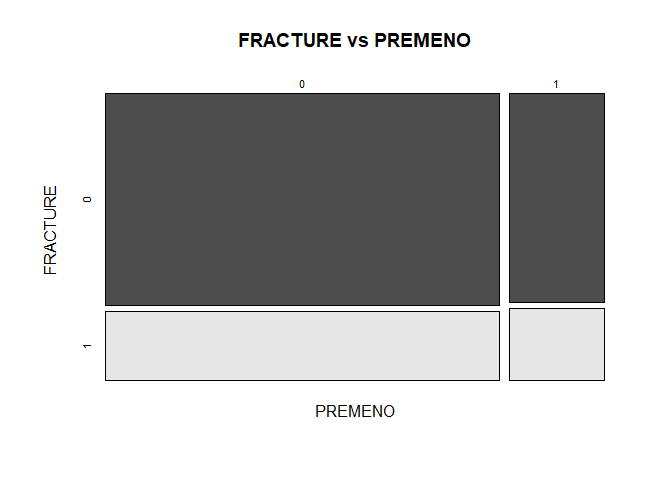

```
##
##
##    Cell Contents
## |-------------------------|
## |                       N |
## |              Expected N |
## | Chi-square contribution |
## |           N / Row Total |
## |           N / Col Total |
## |         N / Table Total |
## |-------------------------|
##
##
## Total Observations in Table:  500
##
##
##              | FRACTURE
##      MOMFRAC |         0 |         1 | Row Total |
## -------------|-----------|-----------|-----------|
##            0 |       334 |       101 |       435 |
##              |   326.250 |   108.750 |           |
##              |     0.184 |     0.552 |           |
##              |     0.768 |     0.232 |     0.870 |
##              |     0.891 |     0.808 |           |
##              |     0.668 |     0.202 |           |
## -------------|-----------|-----------|-----------|
##            1 |        41 |        24 |        65 |
##              |    48.750 |    16.250 |           |
##              |     1.232 |     3.696 |           |
##              |     0.631 |     0.369 |     0.130 |
##              |     0.109 |     0.192 |           |
##              |     0.082 |     0.048 |           |
## -------------|-----------|-----------|-----------|
## Column Total |       375 |       125 |       500 |
##              |     0.750 |     0.250 |           |
## -------------|-----------|-----------|-----------|
##
##
## Statistics for All Table Factors
##
```

[output cut: 30 more lines]

```
##                           |     0.768 |     0.232 |     0.870 |
##                           |     0.891 |     0.808 |           |
##                           |     0.668 |     0.202 |           |
## --------------------------|-----------|-----------|-----------|
##                         1 |        41 |        24 |        65 |
##                           |     1.232 |     3.696 |           |
##                           |     0.631 |     0.369 |     0.130 |
##                           |     0.109 |     0.192 |           |
##                           |     0.082 |     0.048 |           |
## --------------------------|-----------|-----------|-----------|
##              Column Total |       375 |       125 |       500 |
##                           |     0.750 |     0.250 |           |
## --------------------------|-----------|-----------|-----------|
##
##
```

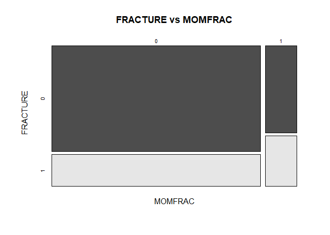

```
##
##
##    Cell Contents
## |-------------------------|
## |                       N |
## |              Expected N |
## | Chi-square contribution |
## |           N / Row Total |
## |           N / Col Total |
## |         N / Table Total |
## |-------------------------|
##
##
## Total Observations in Table:  500
##
##
##              | FRACTURE
##    ARMASSIST |         0 |         1 | Row Total |
## -------------|-----------|-----------|-----------|
##            0 |       250 |        62 |       312 |
##              |   234.000 |    78.000 |           |
##              |     1.094 |     3.282 |           |
##              |     0.801 |     0.199 |     0.624 |
##              |     0.667 |     0.496 |           |
##              |     0.500 |     0.124 |           |
## -------------|-----------|-----------|-----------|
##            1 |       125 |        63 |       188 |
##              |   141.000 |    47.000 |           |
##              |     1.816 |     5.447 |           |
##              |     0.665 |     0.335 |     0.376 |
##              |     0.333 |     0.504 |           |
##              |     0.250 |     0.126 |           |
## -------------|-----------|-----------|-----------|
## Column Total |       375 |       125 |       500 |
##              |     0.750 |     0.250 |           |
## -------------|-----------|-----------|-----------|
##
##
## Statistics for All Table Factors
##
```

[output cut: 30 more lines]

```
##                           |     0.801 |     0.199 |     0.624 |
##                           |     0.667 |     0.496 |           |
##                           |     0.500 |     0.124 |           |
## --------------------------|-----------|-----------|-----------|
##                         1 |       125 |        63 |       188 |
##                           |     1.816 |     5.447 |           |
##                           |     0.665 |     0.335 |     0.376 |
##                           |     0.333 |     0.504 |           |
##                           |     0.250 |     0.126 |           |
## --------------------------|-----------|-----------|-----------|
##              Column Total |       375 |       125 |       500 |
##                           |     0.750 |     0.250 |           |
## --------------------------|-----------|-----------|-----------|
##
##
```

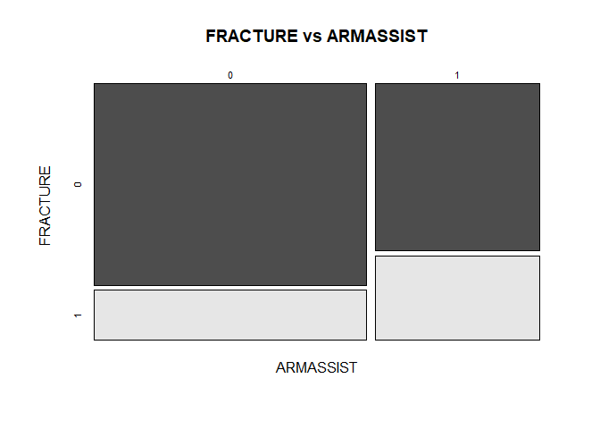

```
##
##
##    Cell Contents
## |-------------------------|
## |                       N |
## |              Expected N |
## | Chi-square contribution |
## |           N / Row Total |
## |           N / Col Total |
## |         N / Table Total |
## |-------------------------|
##
##
## Total Observations in Table:  500
##
##
##              | FRACTURE
##        SMOKE |         0 |         1 | Row Total |
## -------------|-----------|-----------|-----------|
##            0 |       347 |       118 |       465 |
##              |   348.750 |   116.250 |           |
##              |     0.009 |     0.026 |           |
##              |     0.746 |     0.254 |     0.930 |
##              |     0.925 |     0.944 |           |
##              |     0.694 |     0.236 |           |
## -------------|-----------|-----------|-----------|
##            1 |        28 |         7 |        35 |
##              |    26.250 |     8.750 |           |
##              |     0.117 |     0.350 |           |
##              |     0.800 |     0.200 |     0.070 |
##              |     0.075 |     0.056 |           |
##              |     0.056 |     0.014 |           |
## -------------|-----------|-----------|-----------|
## Column Total |       375 |       125 |       500 |
##              |     0.750 |     0.250 |           |
## -------------|-----------|-----------|-----------|
##
##
## Statistics for All Table Factors
##
```

[output cut: 30 more lines]

```
##                           |     0.746 |     0.254 |     0.930 |
##                           |     0.925 |     0.944 |           |
##                           |     0.694 |     0.236 |           |
## --------------------------|-----------|-----------|-----------|
##                         1 |        28 |         7 |        35 |
##                           |     0.117 |     0.350 |           |
##                           |     0.800 |     0.200 |     0.070 |
##                           |     0.075 |     0.056 |           |
##                           |     0.056 |     0.014 |           |
## --------------------------|-----------|-----------|-----------|
##              Column Total |       375 |       125 |       500 |
##                           |     0.750 |     0.250 |           |
## --------------------------|-----------|-----------|-----------|
##
##
```

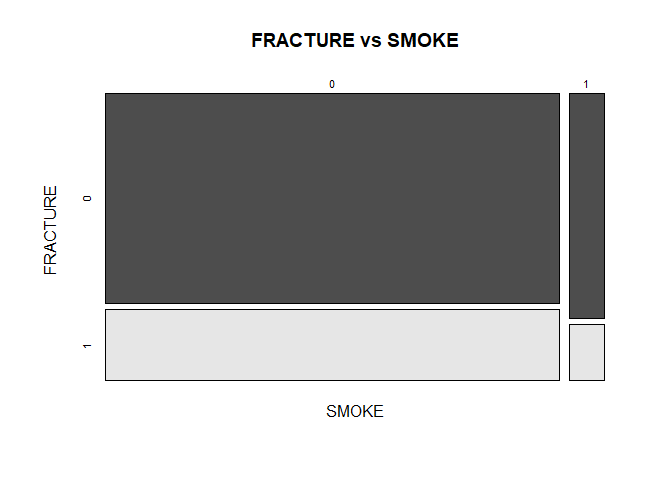

```
##
##
##    Cell Contents
## |-------------------------|
## |                       N |
## |              Expected N |
## | Chi-square contribution |
## |           N / Row Total |
## |           N / Col Total |
## |         N / Table Total |
## |-------------------------|
##
##
## Total Observations in Table:  500
##
##
##              | FRACTURE
##     RATERISK |         0 |         1 | Row Total |
## -------------|-----------|-----------|-----------|
##            1 |       139 |        28 |       167 |
##              |   125.250 |    41.750 |           |
##              |     1.509 |     4.528 |           |
##              |     0.832 |     0.168 |     0.334 |
##              |     0.371 |     0.224 |           |
##              |     0.278 |     0.056 |           |
## -------------|-----------|-----------|-----------|
##            2 |       138 |        48 |       186 |
##              |   139.500 |    46.500 |           |
##              |     0.016 |     0.048 |           |
##              |     0.742 |     0.258 |     0.372 |
##              |     0.368 |     0.384 |           |
##              |     0.276 |     0.096 |           |
## -------------|-----------|-----------|-----------|
##            3 |        98 |        49 |       147 |
##              |   110.250 |    36.750 |           |
##              |     1.361 |     4.083 |           |
##              |     0.667 |     0.333 |     0.294 |
##              |     0.261 |     0.392 |           |
##              |     0.196 |     0.098 |           |
## -------------|-----------|-----------|-----------|
```

[output cut: 40 more lines]

```
##                           |     0.742 |     0.258 |     0.372 |
##                           |     0.368 |     0.384 |           |
##                           |     0.276 |     0.096 |           |
## --------------------------|-----------|-----------|-----------|
##                         3 |        98 |        49 |       147 |
##                           |     1.361 |     4.083 |           |
##                           |     0.667 |     0.333 |     0.294 |
##                           |     0.261 |     0.392 |           |
##                           |     0.196 |     0.098 |           |
## --------------------------|-----------|-----------|-----------|
##              Column Total |       375 |       125 |       500 |
##                           |     0.750 |     0.250 |           |
## --------------------------|-----------|-----------|-----------|
##
##
```

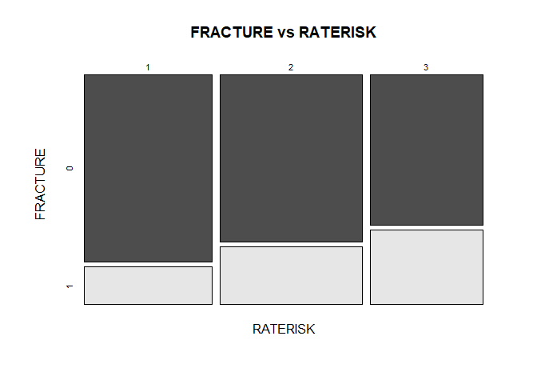

```r
categoricalVarVec  <- c("PRIORFRAC","PREMENO","MOMFRAC","ARMASSIST","SMOKE","RATERISK")
for(categoricalVar in categoricalVarVec){
  CrossTable(dataset[,categoricalVar], dataset$FRACTURE, chisq = TRUE , expected = TRUE, dnn=c(categoricalVar,"FRACTURE"))
  mosaicplot(CrossTable(dataset[ ,categoricalVar], dataset$FRACTURE)$t, main=paste("FRACTURE vs",categoricalVar, sep=" "), xlab=categoricalVar, ylab= "FRACTURE", color=T)
}
```

#Logistic Regression

## Build Model using Training Data

Question of Interest? What are the odds of getting a fracture, given certain conditions?

```r
set.seed(84)
model <- glm(FRACTURE ~ AGE + WEIGHT + HEIGHT + BMI + PRIORFRAC + PREMENO + MOMFRAC + ARMASSIST + SMOKE + RATERISK,data=trainingData, family = "binomial" )
model
```

```
##
## Call:  glm(formula = FRACTURE ~ AGE + WEIGHT + HEIGHT + BMI + PRIORFRAC +
##     PREMENO + MOMFRAC + ARMASSIST + SMOKE + RATERISK, family = "binomial",
##     data = trainingData)
##
## Coefficients:
## (Intercept)          AGE       WEIGHT       HEIGHT          BMI
##   -12.04673      0.03168     -0.10711      0.04735      0.29193
##  PRIORFRAC1     PREMENO1     MOMFRAC1   ARMASSIST1       SMOKE1
##     0.73265      0.04114      0.35482      0.30067     -0.08005
##   RATERISK2    RATERISK3
##     0.38692      0.57786
##
## Degrees of Freedom: 375 Total (i.e. Null);  364 Residual
## Null Deviance:       422.9
## Residual Deviance: 385.4     AIC: 409.4
```

```r
summary(model)
```

```
##
## Call:
## glm(formula = FRACTURE ~ AGE + WEIGHT + HEIGHT + BMI + PRIORFRAC +
##     PREMENO + MOMFRAC + ARMASSIST + SMOKE + RATERISK, family = "binomial",
##     data = trainingData)
##
## Deviance Residuals:
##     Min       1Q   Median       3Q      Max
## -1.4739  -0.7388  -0.5757  -0.1189   2.1597
##
## Coefficients:
##              Estimate Std. Error z value Pr(>|z|)
## (Intercept) -12.04673   13.81668  -0.872  0.38326
## AGE           0.03168    0.01715   1.847  0.06472 .
## WEIGHT       -0.10711    0.09271  -1.155  0.24793
## HEIGHT        0.04735    0.08516   0.556  0.57823
## BMI           0.29193    0.23882   1.222  0.22157
## PRIORFRAC1    0.73265    0.28371   2.582  0.00981 **
## PREMENO1      0.04114    0.32545   0.126  0.89940
## MOMFRAC1      0.35482    0.36197   0.980  0.32697
## ARMASSIST1    0.30067    0.29666   1.014  0.31080
## SMOKE1       -0.08005    0.50041  -0.160  0.87290
## RATERISK2     0.38692    0.32506   1.190  0.23393
## RATERISK3     0.57786    0.34936   1.654  0.09812 .
## ---
## Signif. codes:  0 '***' 0.001 '**' 0.01 '*' 0.05 '.' 0.1 ' ' 1
##
## (Dispersion parameter for binomial family taken to be 1)
##
##     Null deviance: 422.88  on 375  degrees of freedom
## Residual deviance: 385.45  on 364  degrees of freedom
## AIC: 409.45
##
## Number of Fisher Scoring iterations: 4
```

```r
h1 <- hoslem.test(model$y, fitted(model), g = 10) #number of groups to divide dataset into is 10
h1
```

```
##
##  Hosmer and Lemeshow goodness of fit (GOF) test
##
## data:  model$y, fitted(model)
## X-squared = 7.8006, df = 8, p-value = 0.4532
```

## Clustering

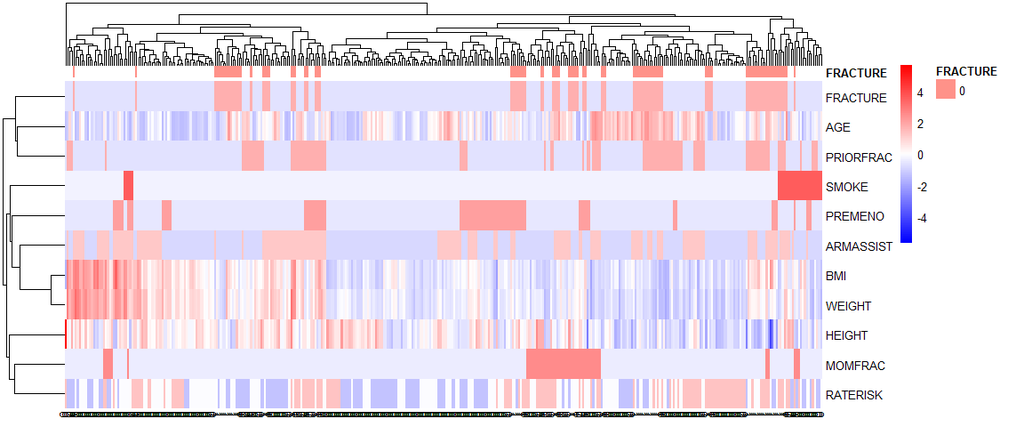

```r
#Lets look at a heatmap using hierarchical clustering to see if the
#response naturually clusters out using the predictors

#Transposting the predictor matrix and giving the response categories its
#row names.
#Get Training Set

# convert factors to numeric for pheatmap
temp <- trainingData
indx <- sapply(temp, is.factor)
temp[indx] <- lapply(temp[indx], function(x) as.numeric(as.character(x)))

dat.train <- temp

dat.train.x <- dat.train[,1:ncol(dat.train)]
dat.train.y <- dat.train$FRACTURE

dat.train.y <- as.factor(as.character(dat.train.y))

#Heatmap
x<-t(dat.train.x)
colnames(x)<-dat.train.y
pheatmap(x,annotation_col=data.frame(FRACTURE=dat.train.y),scale="row",legend=T,color=colorRampPalette(c("blue","white", "red"), space = "rgb")(100))
```

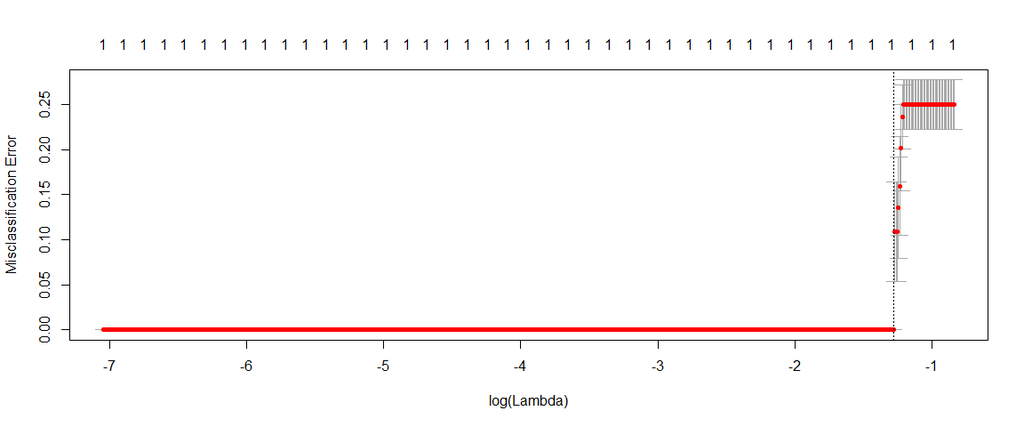

```r
##logistic regression
dat.train.x <- as.matrix(dat.train.x)

cvfit <- cv.glmnet(dat.train.x, dat.train.y, family = "binomial", type.measure = "class", nlambda = 1000)
plot(cvfit)
```

```r
coef(cvfit, s = "lambda.min")
```

```
## 12 x 1 sparse Matrix of class "dgCMatrix"
##                     1
## (Intercept) -1.653758
## AGE          .
## BMI          .
## HEIGHT       .
## WEIGHT       .
## PRIORFRAC    .
## PREMENO      .
## MOMFRAC      .
## ARMASSIST    .
## SMOKE        .
## RATERISK     .
## FRACTURE     1.726571
```